# Data visualization with ggplot2

# Geometric objects | r4ds chapter 3.6

## `geom_smooth()`: smooth line

How are these two plots similar?

- `hwy` vs `displ` line:

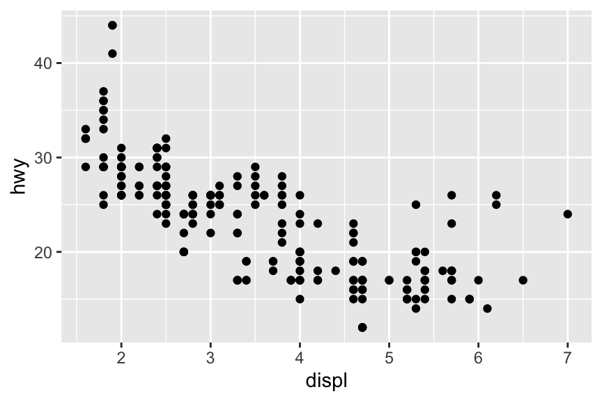

  ```r
  ggplot(data = mpg) +
    geom_point(mapping = aes(x = displ, y = hwy))
  ```

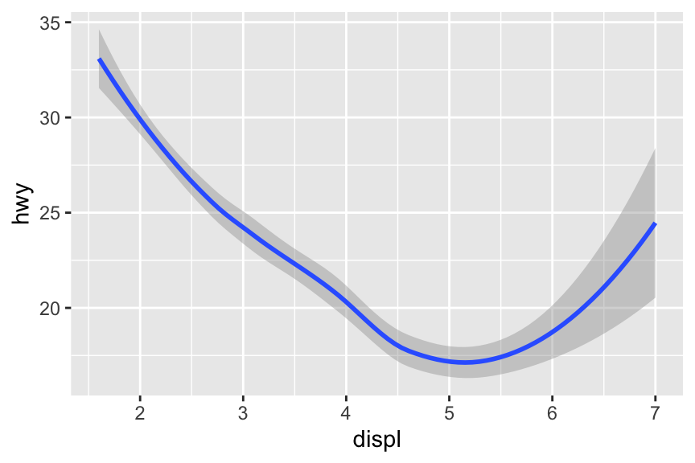

  ```r
  ggplot(data = mpg) +
    geom_smooth(mapping = aes(x = displ, y = hwy))
  ```

## Different line types

- Different line types according to `drv`:

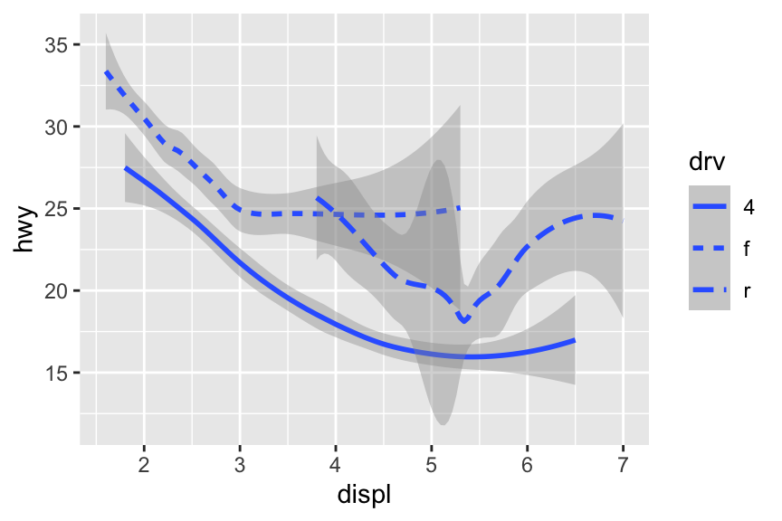

  ```r
  ggplot(data = mpg) +
    geom_smooth(mapping = aes(x = displ, y = hwy, linetype = drv))
  ```

## Different line colors

- Different line colors according to `drv`:

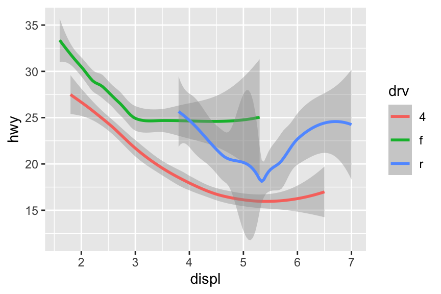

  ```r
  ggplot(data = mpg) +
    geom_smooth(mapping = aes(x = displ, y = hwy, color = drv))
  ```

## Points and lines

- Lines overlaid over scatter plot:

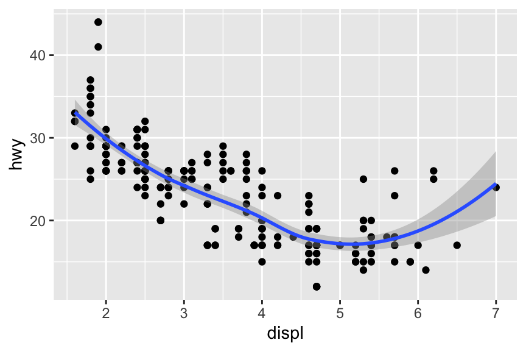

  ```r
  ggplot(data = mpg) +
    geom_point(mapping = aes(x = displ, y = hwy)) +
    geom_smooth(mapping = aes(x = displ, y = hwy))
  ```

- Same as

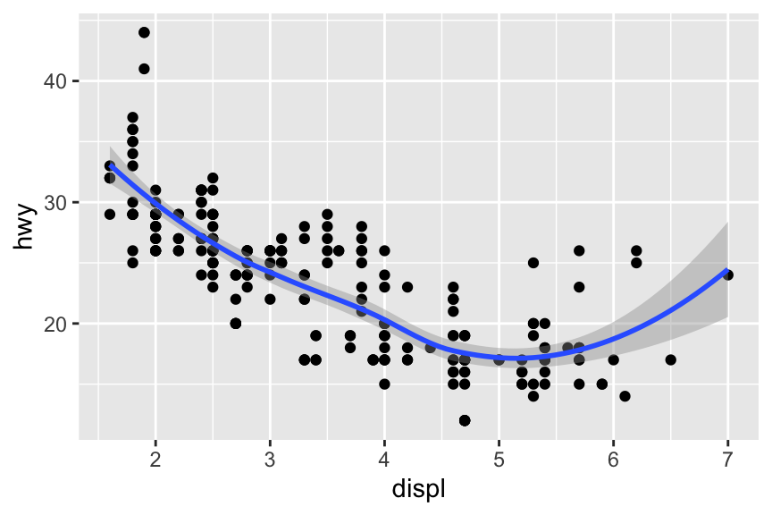

  ```r
  ggplot(data = mpg, mapping = aes(x = displ, y = hwy)) +
    geom_point() + geom_smooth()
  ```

## Aesthetics for each geometric object

- Different aesthetics in different layers:

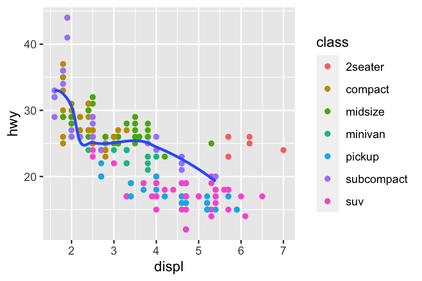

  ```r
  ggplot(data = mpg, mapping = aes(x = displ, y = hwy)) +
    geom_point(mapping = aes(color = class)) +
    geom_smooth(data = filter(mpg, class == "subcompact"), se = FALSE)
  ```

# Bar plots | r4ds chapter 3.7

## `diamonds` data

- `diamonds` data:

  ```r
  diamonds
  ```

  ```
  ## # A tibble: 53,940 × 10
  ##    carat cut       color clarity depth table price     x     y     z
  ##    <dbl> <ord>     <ord> <ord>   <dbl> <dbl> <int> <dbl> <dbl> <dbl>
  ##  1  0.23 Ideal     E     SI2      61.5    55   326  3.95  3.98  2.43
  ##  2  0.21 Premium   E     SI1      59.8    61   326  3.89  3.84  2.31
  ##  3  0.23 Good      E     VS1      56.9    65   327  4.05  4.07  2.31
  ##  4  0.29 Premium   I     VS2      62.4    58   334  4.2   4.23  2.63
  ##  5  0.31 Good      J     SI2      63.3    58   335  4.34  4.35  2.75
  ##  6  0.24 Very Good J     VVS2     62.8    57   336  3.94  3.96  2.48
  ##  7  0.24 Very Good I     VVS1     62.3    57   336  3.95  3.98  2.47
  ##  8  0.26 Very Good H     SI1      61.9    55   337  4.07  4.11  2.53
  ##  9  0.22 Fair      E     VS2      65.1    61   337  3.87  3.78  2.49
  ## 10  0.23 Very Good H     VS1      59.4    61   338  4     4.05  2.39
  ## # ℹ 53,930 more rows
  ```

## Bar plot

- Bar charts, like histograms, frequency polygons, smoothers, and boxplots, plot some computed variables instead of raw data.
- Check available computed variables for a geometric object via help:

  ```r
  ?geom_bar
  ```

- `stat_count()` has a default geom `geom_bar()`.
- Display frequency instead of counts:

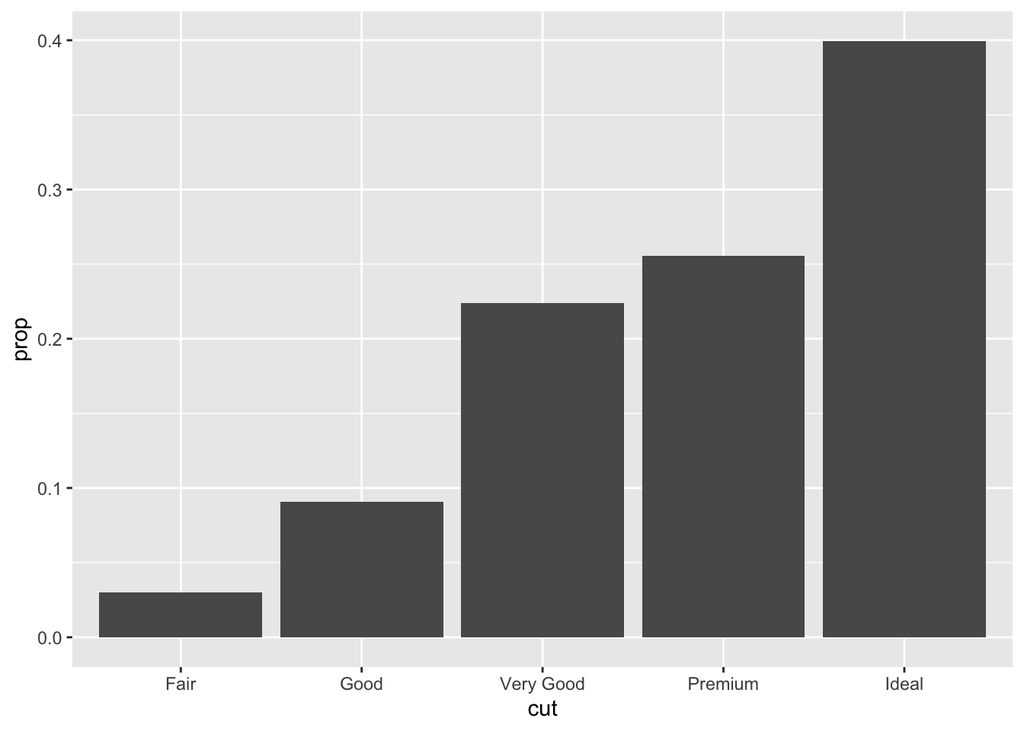

  ```r
  ggplot(data = diamonds) +
    geom_bar(mapping = aes(x = cut, y = stat(prop), group = 1))
  ```

  Note the aesthetics mapping `group=1` overwrites the default grouping (by `cut`) by considering all observations as a group. Without this we get

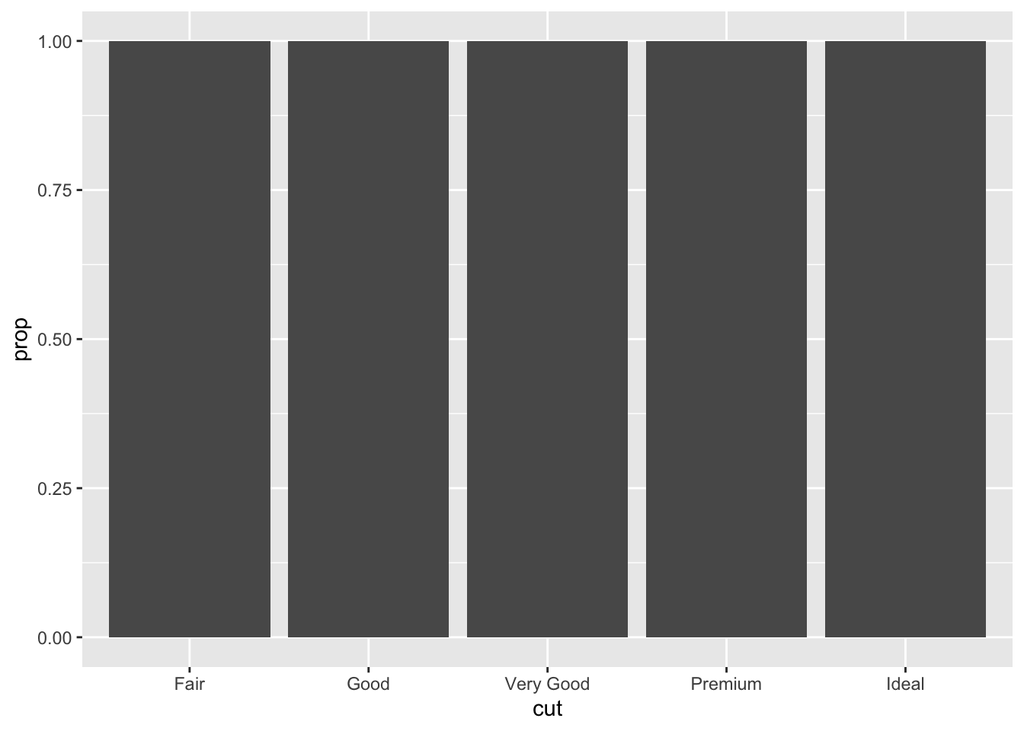

  ```r
  ggplot(data = diamonds) +
    geom_bar(mapping = aes(x = cut, y = stat(prop)))
  ```

## `geom_bar()` vs `geom_col()`

- `geom_bar()` makes the height of the bar proportional to the number of cases in each group (or if the weight aesthetic is supplied, the sum of the weights).

  The height of bar is the number of diamonds in each cut category.
- `geom_col()` makes the heights of the bars to represent values in the data.

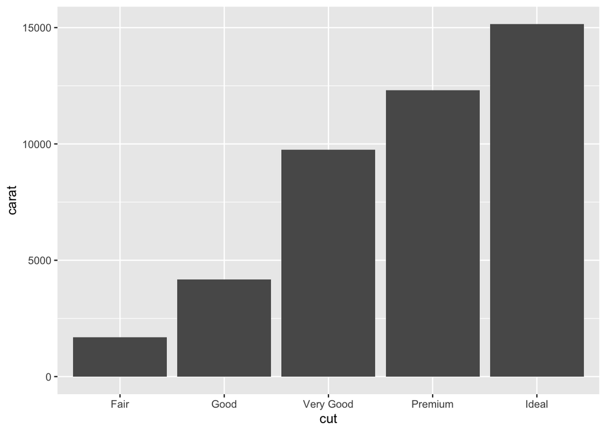

  ```r
  ggplot(data = diamonds) +
    geom_col(mapping = aes(x = cut, y = carat))
  ```

  The height of bar is total carat in each cut category.

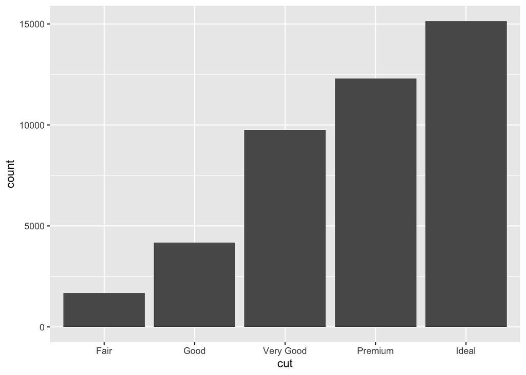

  ```r
  ggplot(data = diamonds) +
    geom_bar(mapping = aes(x = cut, weight = carat))
  ```

# Positional adjustments | r4ds chapter 3.8

- Color bar:

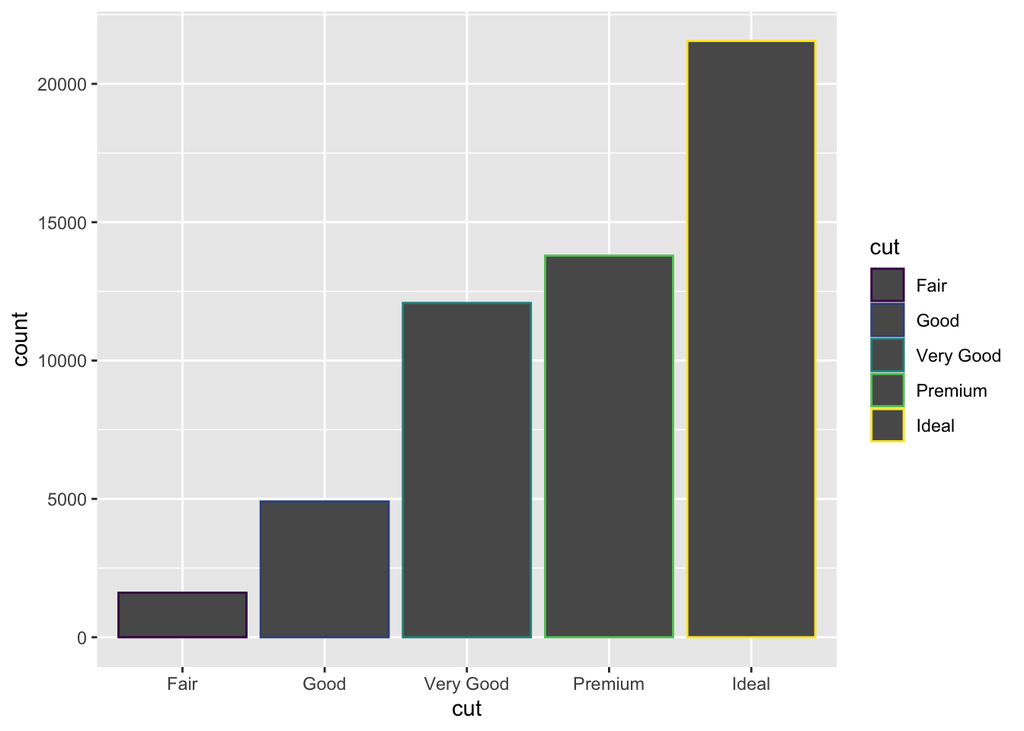

  ```r
  ggplot(data = diamonds) +
    geom_bar(mapping = aes(x = cut, colour = cut))
  ```

- Fill color:

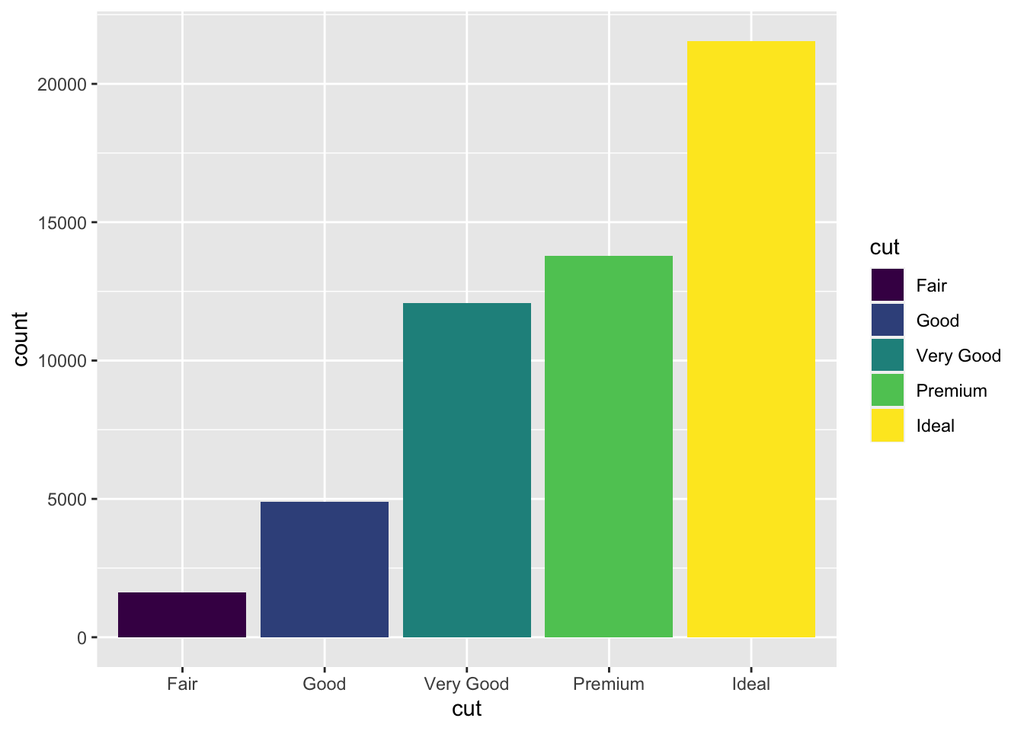

  ```r
  ggplot(data = diamonds) +
    geom_bar(mapping = aes(x = cut, fill = cut))
  ```

- Fill color according to another variable:

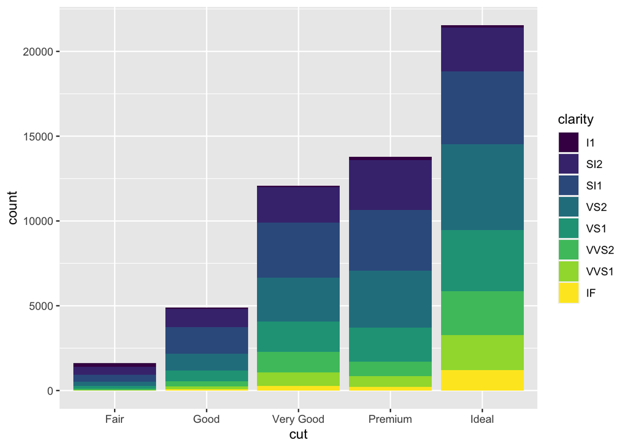

  ```r
  ggplot(data = diamonds) +
    geom_bar(mapping = aes(x = cut, fill = clarity))
  ```

1. The stacking is performed automatically by the **position adjustment** specified by the `position` argument.
2. If you don’t want a stacked bar chart, you can use one of three other options:
   - `"identity"`
   - `"dodge"`
   - `"fill"`
   - `"stack"` (default)
- `position = "identity"` will place each object exactly where it falls in the context of the graph.

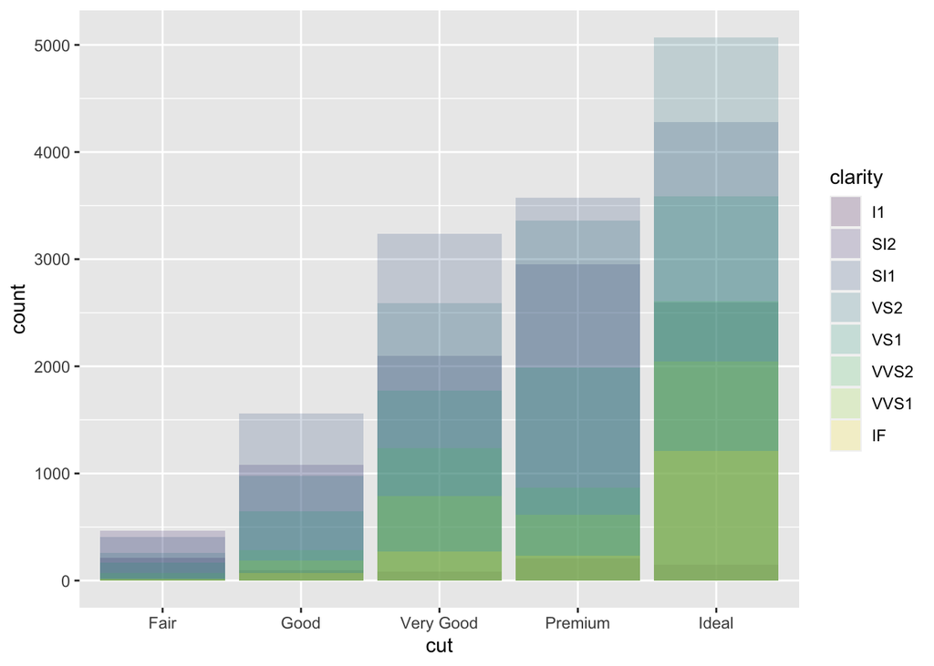

  ```r
  ggplot(data = diamonds, mapping = aes(x = cut, fill = clarity)) +
    geom_bar(alpha = 1/5, position = "identity")
  ```

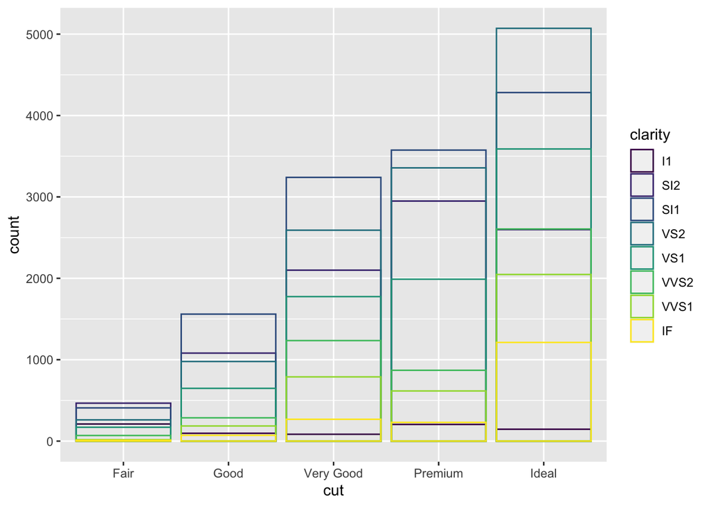

  ```r
  ggplot(data = diamonds, mapping = aes(x = cut, colour = clarity)) +
    geom_bar(fill = NA, position = "identity")
  ```

  - setting `alpha` to a small value makes the bars slightly transparent
  - `identity` position adjustment is more useful (default) for 2d geoms
- `position = "fill"` works like stacking, but makes each set of stacked bars the same height.
  - easier to compare proportions across groups.

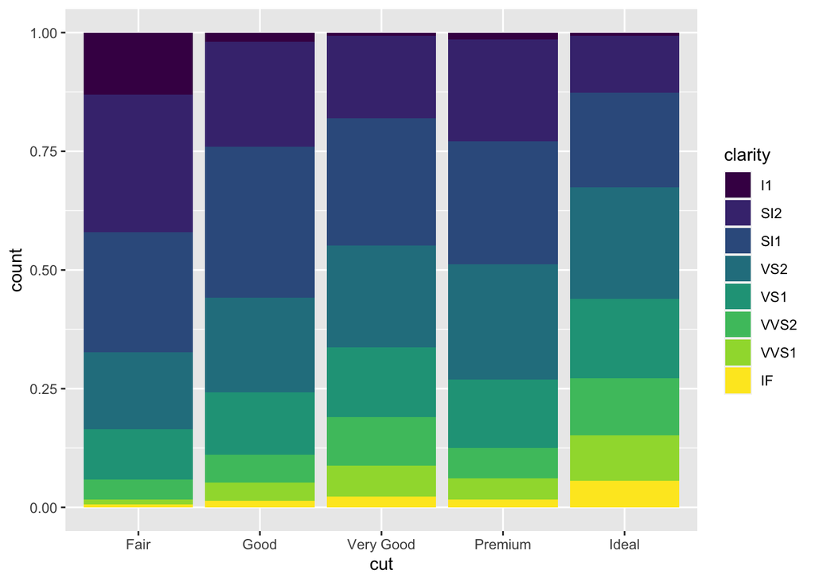

  ```r
  ggplot(data = diamonds) +
    geom_bar(mapping = aes(x = cut, fill = clarity), position = "fill")
  ```

- `position = "dodge"` places overlapping objects directly **beside** one another.

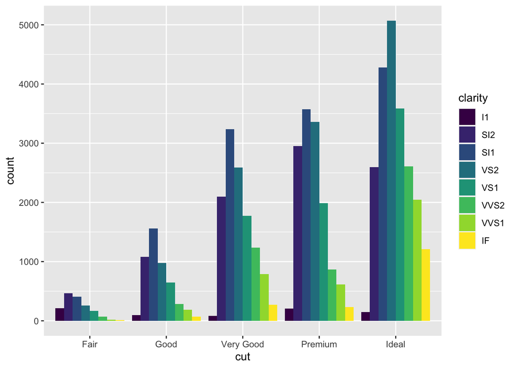

  ```r
  ggplot(data = diamonds) +
    geom_bar(mapping = aes(x = cut, fill = clarity), position = "dodge")
  ```

- `position_jitter()` add random noise to X and Y position of each element to avoid overplotting:

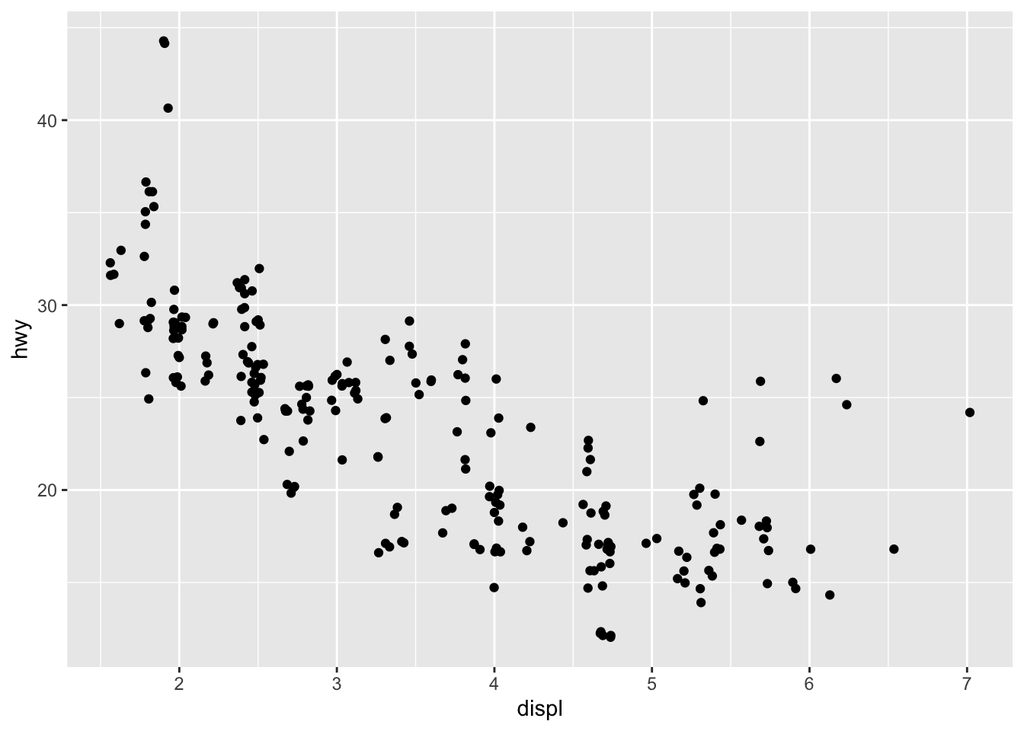

  ```r
  ggplot(data = mpg) +
    geom_point(mapping = aes(x = displ, y = hwy), position = "jitter")
  ```

- `geom_jitter()` is similar:

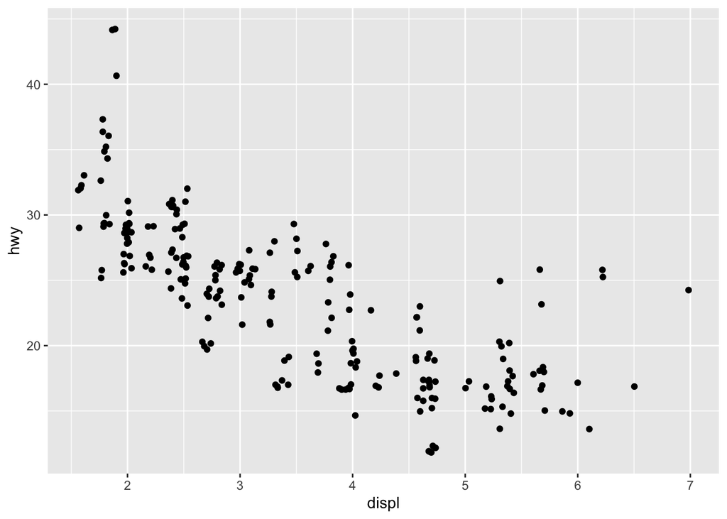

  ```r
  ggplot(data = mpg) +
    geom_jitter(mapping = aes(x = displ, y = hwy))
  ```